# week1_3plotKM_survdiff_logRankTest

Hippo

2020_05_25_12

### what is heart failure

- causes include: coronary heart disease, high blood pressure, arrythmia, alcoholism
- symptoms: shortness of breath, tiredness, swollen ankles
- high mortality and morbidity
- high rate of hospital admission
- readmission high, within 1-4 days of discharge
- hospital admin database gives us data to work with

```r
library(survival)
```

### run survfit() and KMplot

```r
# read in data
g <- read.csv("GMPH_1K_final_2.csv", header = TRUE, sep = ",")
g %>% dim()

# set variable types
g[,"fu_time"] %>% typeof()
fu_time <- g[,"fu_time"]; fu_time %>% head(20)
g[,"death"] %>% typeof()
death <- g[,"death"]; death %>% head(20)
```

```
## [1] 1000   31
## [1] "integer"
##  [1]  416  648  466  441  371   47  656   12  530  551 1059   90  538  289  334
## [16]    5   79  363  195   27
## [1] "integer"
##  [1] 0 0 0 0 0 0 0 0 0 0 0 0 0 0 0 1 0 1 1 0
```

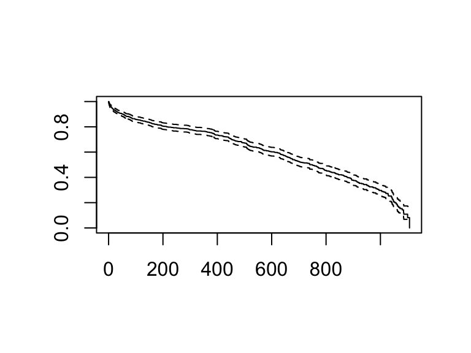

```r
# survfit
km_fit <- survfit(Surv(fu_time, death) ~ 1)
# ~ 1 plots KM estimated probability of survival over time for ALL patients, no comparisons made
plot(km_fit)
```

#### interpret the function

- survfit()
  - fits simple survival model,
  - no predictor given, model has only the intercept (i.e. ~ 1)
- Surv()
  - 2 arguments: follow-up time of each patient + if they died
  - death = 1, people who died by the end of their follow-up period
  - death = 0, people still alive by end of their follow-up period, censored
- survfit() produces KM estimates of “the probabilty of survival over time”,
  - used by plot to produce KM curve

#### table of survival estimates

```r
summary(km_fit, times = c(1:7, 30, 60, 90*(1:10)))
```

```
## Call: survfit(formula = Surv(fu_time, death) ~ 1)
##
##  time n.risk n.event survival std.err lower 95% CI upper 95% CI
##     1    992      12    0.988 0.00346        0.981        0.995
##     2    973       7    0.981 0.00435        0.972        0.989
##     3    963       5    0.976 0.00489        0.966        0.985
##     4    954       6    0.970 0.00546        0.959        0.980
##     5    945       5    0.964 0.00590        0.953        0.976
##     6    938       1    0.963 0.00598        0.952        0.975
##     7    933       1    0.962 0.00606        0.951        0.974
##    30    865      39    0.921 0.00865        0.905        0.939
##    60    809      28    0.891 0.01010        0.871        0.911
##    90    770      24    0.864 0.01117        0.843        0.887
##   180    698      43    0.815 0.01282        0.790        0.841
##   270    653      24    0.787 0.01363        0.760        0.814
##   360    619      21    0.761 0.01428        0.733        0.789
##   450    525      44    0.705 0.01554        0.675        0.736
##   540    429      47    0.639 0.01681        0.607        0.673
##   630    362      32    0.589 0.01765        0.556        0.625
##   720    266      43    0.514 0.01876        0.479        0.552
##   810    190      31    0.448 0.01979        0.411        0.488
##   900    126      26    0.378 0.02098        0.339        0.421
```

- t=1, survival probability is high (99%)
- t=900, survival probability is low (38%)
- { longer you stay in hospital the lower your survival prob?  
  or is this just natural decrease in surv prob over time??? }
- see week1_4 for calculating survfit() output by hand

### run survfit() with groups

```r
g[,"gender"] %>% typeof()
```

```
## [1] "integer"
```

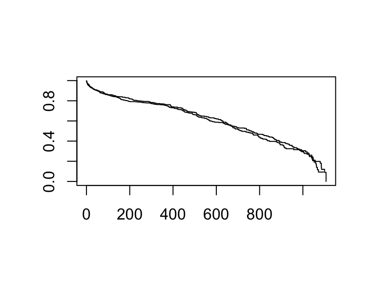

```r
gender <- as.factor(g[,"gender"])
km_gender_fit <- survfit(Surv(fu_time, death) ~ gender)
plot(km_gender_fit)
```

#### compare survival using logRankTest

```r
survdiff(Surv(fu_time, death) ~ gender, rho = 0)
```

```
## Call:
## survdiff(formula = Surv(fu_time, death) ~ gender, rho = 0)
##
##            N Observed Expected (O-E)^2/E (O-E)^2/V
## gender=1 548      268      271    0.0365     0.082
## gender=2 452      224      221    0.0448     0.082
##
##  Chisq= 0.1  on 1 degrees of freedom, p= 0.8
```

- rho = 0 is default
- yields log-rank (aka Mantel-Haenszel) test
- **log-rank test does NOT have proportional hazard assumption**
- { is log-rank test non-parametric? }
- Observed = weighted observed number of events in each group
- Expected = weighted expected number of events in each group

```r
# explore log-rank test
# ?survdiff
# tests if there's a difference btw 2 or more survival curves,
# using rho family of tests

g %>% filter(gender == 1) %>% summarise(., mean(fu_time)) # 460.8942
```

```
##   mean(fu_time)
## 1      460.8942
```

```r
g %>% filter(gender == 2) %>% summarise(., mean(fu_time)) # 472.0841
```

```
##   mean(fu_time)
## 1      472.0841
```

### log-rank test details

- https://en.wikipedia.org/wiki/Logrank_test
- compares survival distributions of 2 samples
- nonparametric
- good when data is right skewed and censored
- **logrank test statistic**
  - compares estimates of hazard function of 2 groups at EACH time point
  - constructed by computing O and E number of events in one group at each time point,
    - then sum to obtain overall summary across all-time points where there was an event
  - more details needed…
- **null hypothesis**
  - 2 groups have identical hazard functions (survival curves)
  - H0: h_1(t) = h_2(t)
- assumptions
  - censoring is unrelated to hazard
  - survival probability same regardless of when subject was recruited (early vs later in study)

### exercise: compare survival of age groups

- age_65+ vs otherwise

```r
age_65plus <- ifelse(g[,"age"] >= 65, 1, 0)
table(age_65plus)
```

```
## age_65plus
##   0   1
## 115 885
```

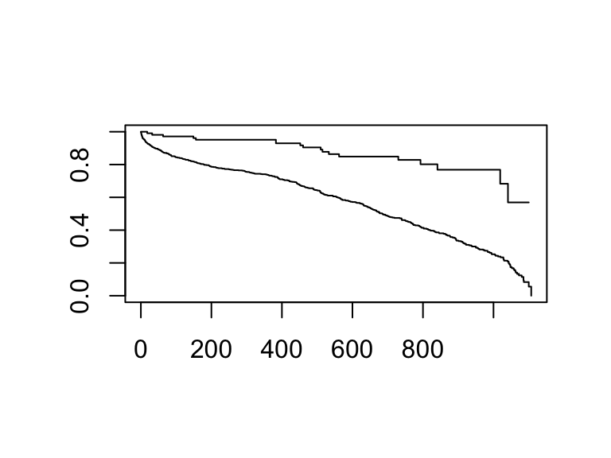

```r
# table(g[, "age"], age_65plus)

km_age65plus_fit <- survfit(Surv(fu_time, death) ~ age_65plus)
plot(km_age65plus_fit)
```

```r
survdiff(Surv(fu_time, death) ~ age_65plus, rho=0)
```

```
## Call:
## survdiff(formula = Surv(fu_time, death) ~ age_65plus, rho = 0)
##
##                N Observed Expected (O-E)^2/E (O-E)^2/V
## age_65plus=0 115       18       67     35.85      41.7
## age_65plus=1 885      474      425      5.65      41.7
##
##  Chisq= 41.7  on 1 degrees of freedom, p= 1e-10
```